# 【Part 1】Project 1 Seattle Airbnb new

## Part 1 of the Project

This part notebook mainly analyzes the dataset of Seattle of Airbnb.

import pkg

```python
import os
import numpy as np
import pandas as pd
import xgboost as xgb
from sklearn.model_selection import GridSearchCV, train_test_split
from sklearn.linear_model import LinearRegression
from sklearn.metrics import r2_score, mean_squared_error
from sklearn.ensemble import RandomForestRegressor
from xgboost import XGBRegressor
import matplotlib.pyplot as plt
import seaborn as sns
plt.style.use('ggplot')

os.chdir('D:\\工作文件\\文档资料\\Python Scripts\\other files\\DSND_Term2_P1\\dataset')
```

```python
lists_boston = pd.read_csv("boston-airbnb-open-data\\listings.csv")
calendar_boston = pd.read_csv("boston-airbnb-open-data\\calendar.csv")
reviews_boston = pd.read_csv("boston-airbnb-open-data\\reviews.csv")
```

```python
lists_seattle = pd.read_csv("seattle-airbnb-open-data\\listings.csv")
calendar_seattle = pd.read_csv("seattle-airbnb-open-data\\calendar.csv")
reviews_seattle = pd.read_csv("seattle-airbnb-open-data\\reviews.csv")
```

Explore Data of Lists Seattle info

```python
lists_seattle.info()
```

```
<class 'pandas.core.frame.DataFrame'>
RangeIndex: 3818 entries, 0 to 3817
Data columns (total 92 columns):
id                                  3818 non-null int64
listing_url                         3818 non-null object
scrape_id                           3818 non-null int64
last_scraped                        3818 non-null object
name                                3818 non-null object
summary                             3641 non-null object
space                               3249 non-null object
description                         3818 non-null object
experiences_offered                 3818 non-null object
neighborhood_overview               2786 non-null object
notes                               2212 non-null object
transit                             2884 non-null object
thumbnail_url                       3498 non-null object
medium_url                          3498 non-null object
picture_url                         3818 non-null object
xl_picture_url                      3498 non-null object
host_id                             3818 non-null int64
host_url                            3818 non-null object
host_name                           3816 non-null object
host_since                          3816 non-null object
host_location                       3810 non-null object
host_about                          2959 non-null object
host_response_time                  3295 non-null object
host_response_rate                  3295 non-null object
host_acceptance_rate                3045 non-null object
host_is_superhost                   3816 non-null object
host_thumbnail_url                  3816 non-null object
host_picture_url                    3816 non-null object
host_neighbourhood                  3518 non-null object
host_listings_count                 3816 non-null float64
host_total_listings_count           3816 non-null float64
host_verifications                  3818 non-null object
host_has_profile_pic                3816 non-null object
host_identity_verified              3816 non-null object
street                              3818 non-null object
neighbourhood                       3402 non-null object
neighbourhood_cleansed              3818 non-null object
```

[output cut: 42 more lines]

```
review_scores_checkin               3160 non-null float64
review_scores_communication         3167 non-null float64
review_scores_location              3163 non-null float64
review_scores_value                 3162 non-null float64
requires_license                    3818 non-null object
license                             0 non-null float64
jurisdiction_names                  3818 non-null object
instant_bookable                    3818 non-null object
cancellation_policy                 3818 non-null object
require_guest_profile_picture       3818 non-null object
require_guest_phone_verification    3818 non-null object
calculated_host_listings_count      3818 non-null int64
reviews_per_month                   3191 non-null float64
dtypes: float64(17), int64(13), object(62)
memory usage: 2.7+ MB
```

## Business Understanding and Data Understanding

Explore Data of lists seattle,we can see how many columns it has

```python
lists_seattle.head()
```

|  | id | listing_url | scrape_id | last_scraped | name | summary | space | description | experiences_offered | neighborhood_overview | ... | review_scores_value | requires_license | license | jurisdiction_names | instant_bookable | cancellation_policy | require_guest_profile_picture | require_guest_phone_verification | calculated_host_listings_count | reviews_per_month |
| --- | --- | --- | --- | --- | --- | --- | --- | --- | --- | --- | --- | --- | --- | --- | --- | --- | --- | --- | --- | --- | --- |
| 0 | 241032 | https://www.airbnb.com/rooms/241032 | 20160104002432 | 2016-01-04 | Stylish Queen Anne Apartment | NaN | Make your self at home in this charming one-be... | Make your self at home in this charming one-be... | none | NaN | ... | 10.0 | f | NaN | WASHINGTON | f | moderate | f | f | 2 | 4.07 |
| 1 | 953595 | https://www.airbnb.com/rooms/953595 | 20160104002432 | 2016-01-04 | Bright & Airy Queen Anne Apartment | Chemically sensitive? We've removed the irrita... | Beautiful, hypoallergenic apartment in an extr... | Chemically sensitive? We've removed the irrita... | none | Queen Anne is a wonderful, truly functional vi... | ... | 10.0 | f | NaN | WASHINGTON | f | strict | t | t | 6 | 1.48 |
| 2 | 3308979 | https://www.airbnb.com/rooms/3308979 | 20160104002432 | 2016-01-04 | New Modern House-Amazing water view | New modern house built in 2013. Spectacular s... | Our house is modern, light and fresh with a wa... | New modern house built in 2013. Spectacular s... | none | Upper Queen Anne is a charming neighborhood fu... | ... | 10.0 | f | NaN | WASHINGTON | f | strict | f | f | 2 | 1.15 |
| 3 | 7421966 | https://www.airbnb.com/rooms/7421966 | 20160104002432 | 2016-01-04 | Queen Anne Chateau | A charming apartment that sits atop Queen Anne... | NaN | A charming apartment that sits atop Queen Anne... | none | NaN | ... | NaN | f | NaN | WASHINGTON | f | flexible | f | f | 1 | NaN |
| 4 | 278830 | https://www.airbnb.com/rooms/278830 | 20160104002432 | 2016-01-04 | Charming craftsman 3 bdm house | Cozy family craftman house in beautiful neighb... | Cozy family craftman house in beautiful neighb... | Cozy family craftman house in beautiful neighb... | none | We are in the beautiful neighborhood of Queen ... | ... | 9.0 | f | NaN | WASHINGTON | f | strict | f | f | 1 | 0.89 |

5 rows × 92 columns

I will try to visualize the table "lists_seattle" depending to different kind of features

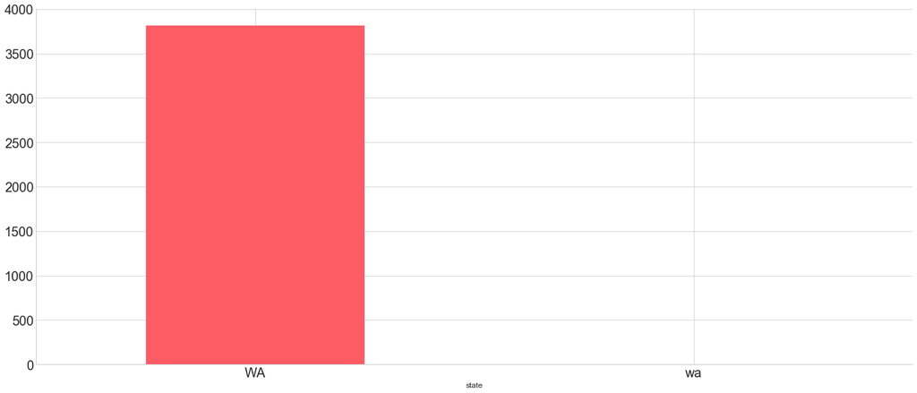

```python
lists_seattle.state.value_counts(dropna=False).plot(kind='bar',color='#FD5C64',rot = 0,figsize=(24,10),fontsize=20)
plt.xlabel("state")
sns.despine()
```

AS we can see,all booking datas come from the state,Washington.

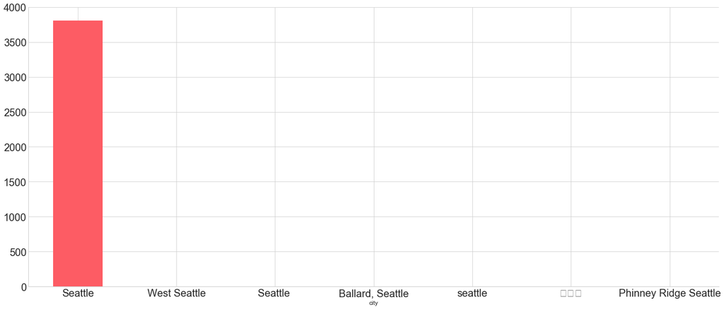

```python
lists_seattle.city.value_counts(dropna=False).plot(kind='bar',color='#FD5C64',rot = 0,figsize=(24,10),fontsize=20)
plt.xlabel("city")
sns.despine()
```

AS we can see,all booking datas come from the city,Seattle.

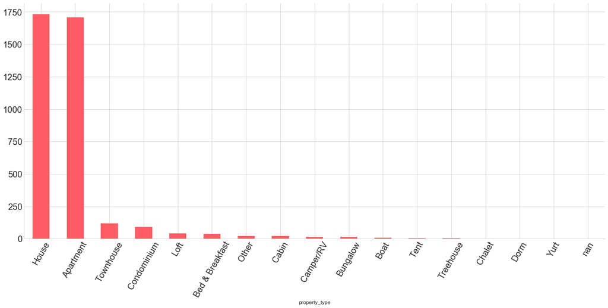

```python
lists_seattle.property_type.value_counts(dropna=False).plot(kind='bar',color='#FD5C64',rot = 0,figsize=(24,10),fontsize=20)
plt.xlabel("property_type")
plt.xticks(rotation=60)
sns.despine()
```

From the picture above,I find mainly property types are "House" and "Apartment".

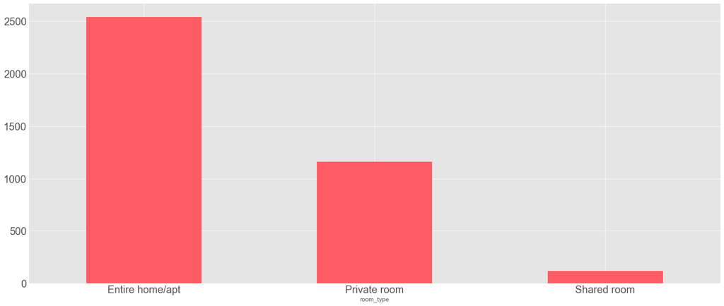

```python
lists_seattle.room_type.value_counts(dropna=False).plot(kind='bar',color='#FD5C64',rot = 0,figsize=(24,10),fontsize=20)
plt.xlabel("room_type")
# plt.xticks(rotation=60)
sns.despine()
```

From the picture above,I find mainly room types are "Entire home" and "Private room".

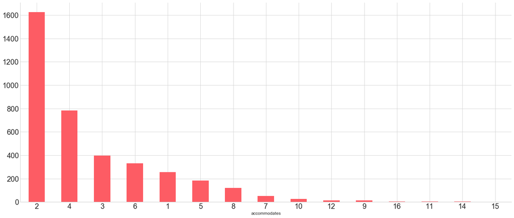

```python
lists_seattle.accommodates.value_counts(dropna=False).plot(kind='bar',color='#FD5C64',rot = 0,figsize=(24,10),fontsize=20)
plt.xlabel("accommodates")
sns.despine()
```

As the picture above, I can see,most of accommodates are 2,3,4.

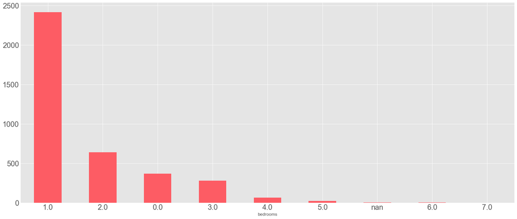

```python
lists_seattle.bedrooms.value_counts(dropna=False).plot(kind='bar',color='#FD5C64',rot = 0,figsize=(24,10),fontsize=20)
plt.xlabel("bedrooms")
sns.despine()
```

As the picture above,I can see,most of bedrooms are 0,1,2.

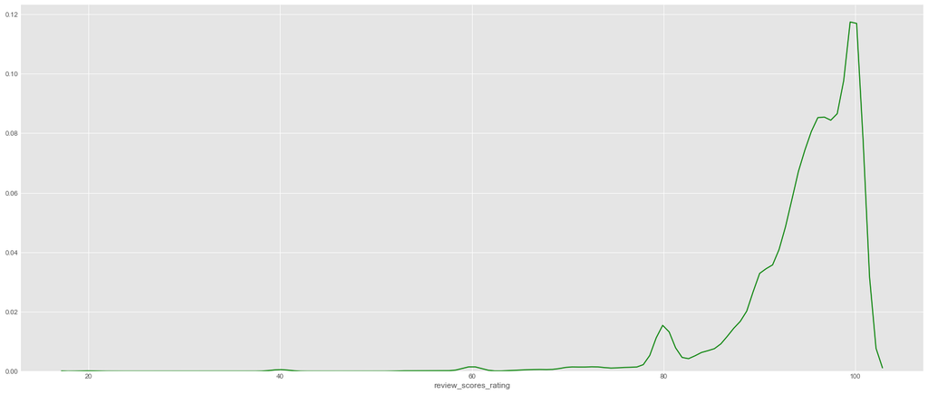

```python
sns.distplot(lists_seattle.review_scores_rating.dropna(),hist=False,color="g")
plt.xlabel('review_scores_rating')
# plt.xlim([0,100])
sns.despine()
```

Most of review scores rating are more than 80.

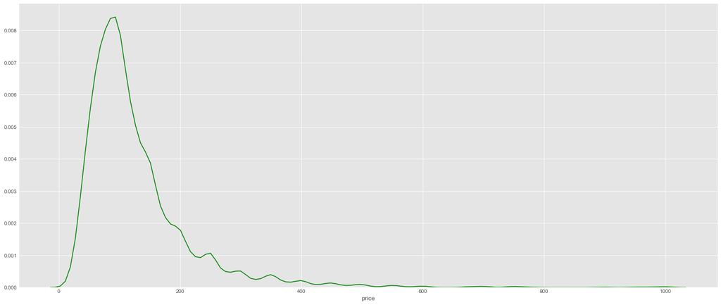

```python
lists_seattle['price'] = lists_seattle['price'].str.replace('$', '')
lists_seattle['price'] = lists_seattle['price'].str.replace(',', '').astype('float64')
sns.distplot(lists_seattle.price.dropna(),hist=False,color="g")
plt.xlabel('price')
# plt.xlim([0,10])
sns.despine()
```

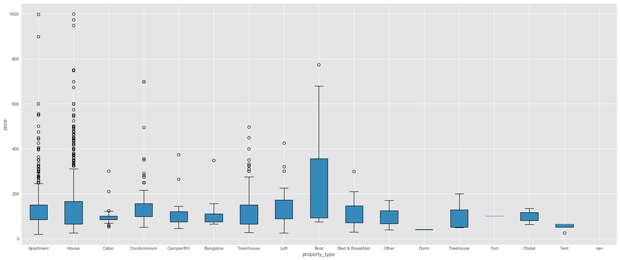

```python
lists_seattle_price  = lists_seattle[np.isfinite(lists_seattle['price'])]
property_type = lists_seattle_price.property_type.unique()
data_to_plot = []

## create the dataplot from the property_type dataframe
for property in property_type:
    data_to_plot.append(lists_seattle[lists_seattle.property_type == property].price)

## create a figure instance
fig = plt.figure(1,figsize(24,10))
# Create an axes instance
ax = fig.add_subplot(111)


# Create the boxplot
bp = ax.boxplot(data_to_plot,vert=True,patch_artist=True)

## Custom x-axis labels
ax.set_xticklabels(lists_seattle.property_type.unique())


plt.xlabel("property_type")
plt.ylabel("price")
# plt.ylim([25,50])
plt.show()
```

From the picture above,the propert type "Boat" has higher booking price than other propert types, the propert type "House" has some much higher price booking data.

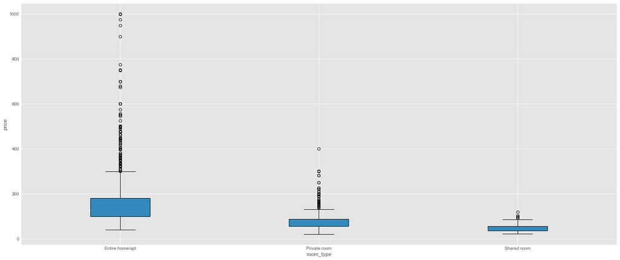

```python
lists_seattle_price  = lists_seattle[np.isfinite(lists_seattle['price'])]
room_type = lists_seattle_price.room_type.unique()
data_to_plot = []

## create the dataplot from the room_type dataframe
for room in room_type:
    data_to_plot.append(lists_seattle[lists_seattle.room_type == room].price)

## create a figure instance
fig = plt.figure(1,figsize(24,10))
# Create an axes instance
ax = fig.add_subplot(111)


# Create the boxplot
bp = ax.boxplot(data_to_plot,vert=True,patch_artist=True)

## Custom x-axis labels
ax.set_xticklabels(lists_seattle.room_type.unique())


plt.xlabel("room_type")
plt.ylabel("price")
# plt.ylim([25,50])
plt.show()
```

The room type "Entire home" has higher price than other room types

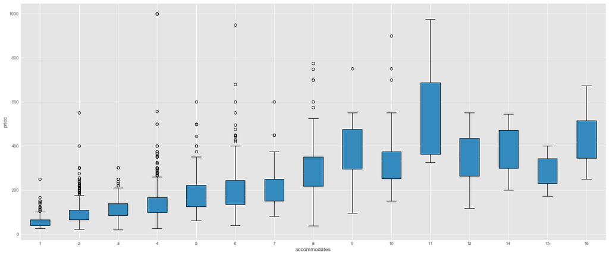

```python
lists_seattle_price  = lists_seattle[np.isfinite(lists_seattle['price'])]
lists_seattle_price['accommodates'] = lists_seattle_price['accommodates'].astype('int')
accommodates = np.sort(lists_seattle_price.accommodates.unique())
data_to_plot = []

## create the dataplot from the accommodates dataframe
for accommodate in accommodates:
    data_to_plot.append(lists_seattle[lists_seattle.accommodates == accommodate].price)

## create a figure instance
fig = plt.figure(1,figsize(24,10))
# Create an axes instance
ax = fig.add_subplot(111)


# Create the boxplot
bp = ax.boxplot(data_to_plot,vert=True,patch_artist=True)

## Custom x-axis labels
ax.set_xticklabels(np.sort(lists_seattle.accommodates.unique()))


plt.xlabel("accommodates")
plt.ylabel("price")
# plt.ylim([25,50])
plt.show()
```

With the accommodates become bigger,the price becomes higher.